# analysis slides

## Which Feature of This Dataset Best Describes the Sale Price?

```python
#load in dataset
df = pd.read_csv('dataset.csv')
df.head()
```

|  | Id | MSSubClass | MSZoning | LotFrontage | LotArea | Street | Alley | LotShape | LandContour | Utilities | LotConfig | LandSlope | Neighborhood | Condition1 | Condition2 | BldgType | HouseStyle | OverallQual | OverallCond | YearBuilt | YearRemodAdd | RoofStyle | RoofMatl | Exterior1st | Exterior2nd | MasVnrType | MasVnrArea | ExterQual | ExterCond | … |
| --- | --- | --- | --- | --- | --- | --- | --- | --- | --- | --- | --- | --- | --- | --- | --- | --- | --- | --- | --- | --- | --- | --- | --- | --- | --- | --- | --- | --- | --- | --- |
| 0 | 1 | 60 | RL | 65.0 | 8450 | Pave | NaN | Reg | Lvl | AllPub | Inside | Gtl | CollgCr | Norm | Norm | 1Fam | 2Story | 7 | 5 | 2003 | 2003 | Gable | CompShg | VinylSd | VinylSd | BrkFace | 196.0 | Gd | TA | … |
| 1 | 2 | 20 | RL | 80.0 | 9600 | Pave | NaN | Reg | Lvl | AllPub | FR2 | Gtl | Veenker | Feedr | Norm | 1Fam | 1Story | 6 | 8 | 1976 | 1976 | Gable | CompShg | MetalSd | MetalSd | None | 0.0 | TA | TA | … |
| 2 | 3 | 60 | RL | 68.0 | 11250 | Pave | NaN | IR1 | Lvl | AllPub | Inside | Gtl | CollgCr | Norm | Norm | 1Fam | 2Story | 7 | 5 | 2001 | 2002 | Gable | CompShg | VinylSd | VinylSd | BrkFace | 162.0 | Gd | TA | … |
| 3 | 4 | 70 | RL | 60.0 | 9550 | Pave | NaN | IR1 | Lvl | AllPub | Corner | Gtl | Crawfor | Norm | Norm | 1Fam | 2Story | 7 | 5 | 1915 | 1970 | Gable | CompShg | Wd Sdng | Wd Shng | None | 0.0 | TA | TA | … |
| 4 | 5 | 60 | RL | 84.0 | 14260 | Pave | NaN | IR1 | Lvl | AllPub | FR2 | Gtl | NoRidge | Norm | Norm | 1Fam | 2Story | 8 | 5 | 2000 | 2000 | Gable | CompShg | VinylSd | VinylSd | BrkFace | 350.0 | Gd | TA | … |

### Frequency Distribution of Sale Price

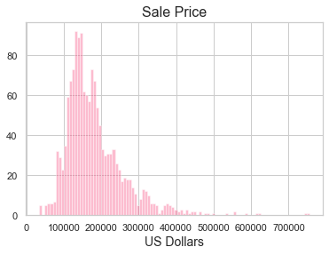

```python
sns.set(style="whitegrid")
sns.distplot(df['SalePrice'], kde=False, color='#F85888', bins=100)
plt.title('Sale Price', fontsize=16)
plt.xlabel('US Dollars', fontsize=14)
```

### Kernel Density Estimation Plot of Sale Price

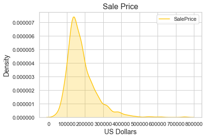

```python
sns.set(style="whitegrid")
sns.kdeplot(df['SalePrice'], color='#fec508', shade=True)
plt.title('Sale Price', fontsize=16)
plt.xlabel('US Dollars', fontsize=14)
plt.ylabel('Density', fontsize=14)
```

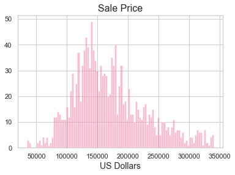

```python
sns.set(style="whitegrid")
sns.distplot(new_df['SalePrice'], kde=False, color='#F85888', bins=100)
plt.title('Sale Price', fontsize=16)
plt.xlabel('US Dollars', fontsize=14)
```

### Correlation Analysis

The main question we seek to answer is which individual feature has the most impact on the sales price? To me, the best way to measure that is to examine the relationship between the features and the sales price.

Pandas .corr() function is a very convenient way to find pairwise correlation of the columns within the dataframe by creating a correlation matrix. I'm looking for multicollinearity and features that don't have much correlation with the sale price itself. The only caveat is that this function excludes nonnumerical data.

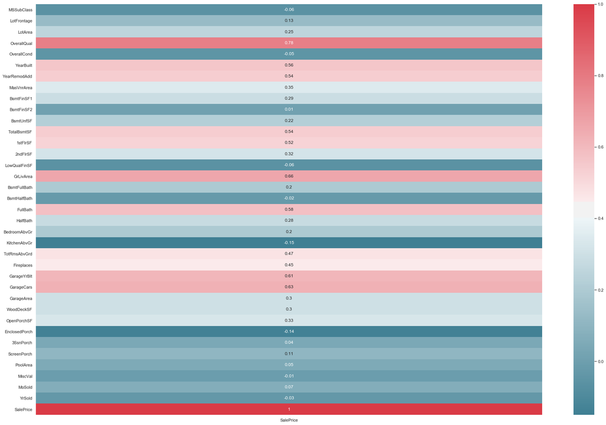

```python
f, ax = plt.subplots(figsize=(30,20))
cmap = sns.diverging_palette(220, 10, as_cmap=True)
sns.heatmap(corr[['SalePrice']], cmap=cmap, annot=True)
```

```python
new_df = df
new_corr = new_corr[abs(corr["SalePrice"])>0.5].T
new_corr[["SalePrice"]]
```

|  | SalePrice |
| --- | --- |
| OverallQual | 0.78 |
| YearBuilt | 0.56 |
| YearRemodAdd | 0.54 |
| TotalBsmtSF | 0.54 |
| 1stFlrSF | 0.52 |
| GrLivArea | 0.66 |
| FullBath | 0.58 |
| GarageYrBlt | 0.61 |
| GarageCars | 0.63 |
| SalePrice | 1.00 |

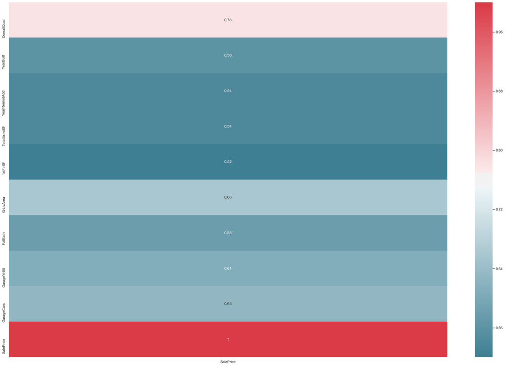

```python
f, ax = plt.subplots(figsize=(30,20))
cmap = sns.diverging_palette(220, 10, as_cmap=True)
sns.heatmap(new_corr[['SalePrice']], cmap=cmap, annot=True)
```

#### I want to plot some of the most correlated features with the sale price and see what we discover.

#### Overall Quality x Sale Price

I see a strong positive correlation between the overall quality and the sales price.

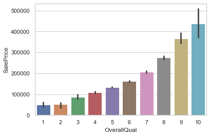

```python
#comparing overall quality to sales price
sns.barplot(x=new_df['OverallQual'], y=new_df['SalePrice'])
```

#### Above Ground Living Area x Sale Price

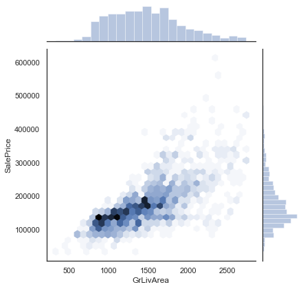

```python
sns.set(style="white")
sns.color_palette("Blues")
g = sns.jointplot("GrLivArea", "SalePrice", data=new_df, kind="hex")
```

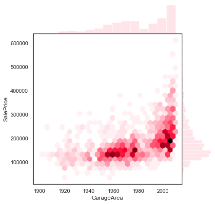

```python
g = sns.jointplot("GarageArea", "SalePrice", data=new_df, kind="hex", space=0, color="pink")
```

### Feature Engineering

```python
from sklearn.model_selection import cross_val_score, GridSearchCV, train_test_split
from sklearn.ensemble import RandomForestRegressor, GradientBoostingRegressor
from sklearn.metrics import accuracy_score, r2_score, mean_squared_error
from sklearn.preprocessing import OneHotEncoder, LabelEncoder, StandardScaler
```

### Binary Variables

We only have three binary variables in the training data. These features are the type of street, the type of utilities, and whether there is central air or not.

```python
n_rows = len(X_train)
X_train_binary = X_train[binary_cols]
X_train_binary.head()
```

|  | Street | Utilities | CentralAir |
| --- | --- | --- | --- |
| 1397 | Pave | AllPub | Y |
| 615 | Pave | AllPub | Y |
| 836 | Pave | AllPub | Y |
| 959 | Pave | AllPub | Y |
| 831 | Pave | AllPub | Y |

```python
from sklearn.feature_selection import f_regression

f, p_val = f_regression(X_train_b_enc, y_train)
```

```python
f_reg_df = pd.DataFrame(np.array([f, p_val]).T, index = X_train_b_enc.columns, columns = ['f-statistic', 'p-value'])
binary_features = f_reg_df[f_reg_df['p-value'] < f_reg_df['f-statistic']].sort_values(by = 'f-statistic', ascending = False)
binary_features
```

[output not shown]

### Multivariate Features

```python
#Label encoding
X_train_cat = X_train[categor_cols]
X_train_cat_le = enc.fit_transform(X_train_cat)
X_test_cat_le = enc.transform(X_test[categor_cols])
X_train_cat_le.head()
```

|  | MSSubClass | MSZoning | LotShape | LandContour | LotConfig | LandSlope | Neighborhood | Condition1 | Condition2 | BldgType | HouseStyle | OverallQual | OverallCond | RoofStyle | RoofMatl | Exterior1st | Exterior2nd | MasVnrType | ExterQual | ExterCond | Foundation | BsmtQual | BsmtCond | BsmtExposure | BsmtFinType1 | BsmtFinType2 | Heating | HeatingQC | Electrical | … |
| --- | --- | --- | --- | --- | --- | --- | --- | --- | --- | --- | --- | --- | --- | --- | --- | --- | --- | --- | --- | --- | --- | --- | --- | --- | --- | --- | --- | --- | --- | --- |
| 1397 | 6 | 4 | 3 | 3 | 4 | 0 | 3 | 2 | 2 | 0 | 5 | 3 | 6 | 1 | 0 | 7 | 8 | 3 | 3 | 2 | 0 | 4 | 4 | 2 | 6 | 6 | 1 | 0 | 3 | … |
| 615 | 9 | 3 | 3 | 3 | 4 | 0 | 12 | 1 | 2 | 0 | 6 | 4 | 5 | 1 | 0 | 7 | 8 | 1 | 3 | 1 | 2 | 4 | 4 | 1 | 2 | 6 | 1 | 0 | 3 | … |
| 836 | 1 | 4 | 3 | 3 | 4 | 0 | 17 | 2 | 2 | 0 | 2 | 3 | 4 | 1 | 0 | 11 | 13 | 3 | 3 | 2 | 0 | 4 | 4 | 4 | 5 | 6 | 1 | 2 | 3 | … |
| 959 | 12 | 1 | 3 | 3 | 2 | 0 | 21 | 2 | 2 | 3 | 5 | 5 | 3 | 3 | 0 | 7 | 8 | 3 | 2 | 2 | 2 | 2 | 4 | 4 | 0 | 6 | 1 | 0 | 3 | … |
| 831 | 12 | 1 | 3 | 3 | 4 | 0 | 21 | 2 | 2 | 4 | 5 | 5 | 3 | 1 | 0 | 7 | 8 | 3 | 3 | 2 | 2 | 2 | 4 | 4 | 6 | 6 | 1 | 0 | 3 | … |

The first technique I used is an sklearn feature selection module called Mutual Information. Mutual information measures the dependency between X and y and calculates which features are most relevant. I then displayed the top 10 columns using a heatmap! So far, it looks like Overall Quality is a highly influential feature according to this module.

I'm going to try a few other methods to see whether they confirm these results.

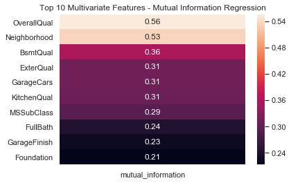

```python
mi = mutual_info_regression(X_train_cat_le, y_train, discrete_features = True, n_neighbors=5, copy=True, random_state=None)

mi_df = pd.DataFrame(mi, index=categor_cols, columns=['mutual_information'])
mi_top10_feat = mi_df.sort_values(by = 'mutual_information', ascending=False).head(10)
sns.heatmap(data = mi_top10_feat, annot=True )
plt.title('Top 10 Multivariate Features - Mutual Information Regression')
```

The next method that came highly recommended from multiple sources is to run a a Random Forest Regressor model from sklearn. It has a feature importance method that accounts for the average of how much each feature decreases the impurity in a tree. The benefits of using this ensemble technique is that it draws from wisdom of the crowd instead of relying on a single tree.

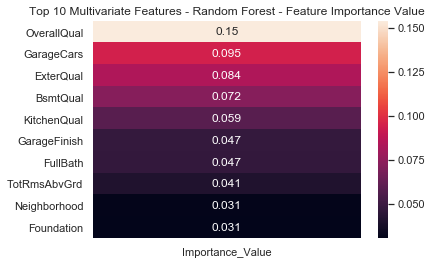

```python
rfr_cat_feat = pd.DataFrame(rfr_cat_new.feature_importances_, X_train_cat.columns, columns=['Importance_Value'])
rfr_cat_top10 = rfr_cat_feat.sort_values(by = ['Importance_Value'], ascending=False).head(10)
sns.heatmap(data = rfr_cat_top10, annot=True )
plt.title('Top 10 Multivariate Features - Random Forest - Feature Importance Value')
```

```python
# Subset of intersection of mi and rfr
important_cols = set(mi_top10_feat.index).intersection(rfr_cat_top10.index)
important_cols
```

```
{'BsmtQual',
 'ExterQual',
 'Foundation',
 'FullBath',
 'GarageCars',
 'GarageFinish',
 'KitchenQual',
 'Neighborhood',
 'OverallQual'}
```

### Multivariate Columns with > 25 Categories

This segment is mostly measuring continuous variables and is filtered by columns with more than 25 unique variables.

```python
continuous_cols = categorical_filter(X_train, 25, len(X_train))
print('# of Continuous Variables (with more than 25 categories) = ',len(continuous_cols))
```

```
# of Continuous Variables (with more than 25 categories) =  18
```

```python
train_cont = X_train[continuous_cols]
train_cont[['GarageArea']] = train_cont[['GarageArea']].astype(int)
train_cont.head()
```

|  | LotFrontage | LotArea | YearBuilt | YearRemodAdd | MasVnrArea | BsmtFinSF1 | BsmtFinSF2 | BsmtUnfSF | TotalBsmtSF | 1stFlrSF | 2ndFlrSF | GrLivArea | GarageYrBlt | GarageArea | WoodDeckSF | OpenPorchSF | EnclosedPorch | ScreenPorch |
| --- | --- | --- | --- | --- | --- | --- | --- | --- | --- | --- | --- | --- | --- | --- | --- | --- | --- | --- |
| 1397 | 51.0 | 6120 | 1920 | 2004 | 0.0 | 0 | 0 | 939 | 939 | 939 | 574 | 1513 | 180 | 1933 | 24 | 0 | 150 | 0 |
| 615 | 80.0 | 8800 | 1963 | 1963 | 156.0 | 763 | 0 | 173 | 936 | 1054 | 0 | 1054 | 480 | 1963 | 120 | 0 | 0 | 0 |
| 836 | 90.0 | 8100 | 1948 | 1973 | 0.0 | 338 | 0 | 1221 | 1559 | 1559 | 0 | 1559 | 812 | 1948 | 0 | 116 | 230 | 0 |
| 959 | 24.0 | 2572 | 1999 | 1999 | 0.0 | 604 | 0 | 92 | 696 | 696 | 720 | 1416 | 484 | 1999 | 0 | 44 | 0 | 0 |
| 831 | 30.0 | 3180 | 2005 | 2005 | 0.0 | 0 | 0 | 600 | 600 | 520 | 600 | 1200 | 480 | 2005 | 0 | 166 | 0 | 0 |

I am going to run another Random Forest Regressor model on the continuous data to see how they rank as far as feature importance. I also did another grid search because the optimal number of estimators will be different for these columns.

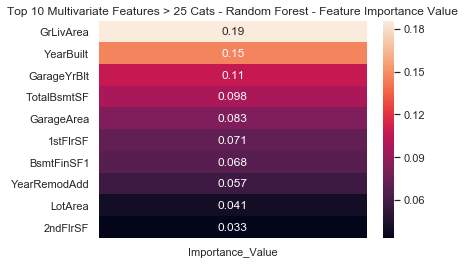

```python
rfr_cont_feat = pd.DataFrame(rfr_cont_new.feature_importances_, train_cont.columns, columns=['Importance_Value'])
rfr_cont_rank = rfr_cont_feat.sort_values(by = ['Importance_Value'], ascending=False).head(10)
sns.heatmap(data = rfr_cont_rank, annot=True )
plt.title('Top 10 Multivariate Features > 25 Cats - Random Forest - Feature Importance Value')
```

The next ensemble technique I decided to explore was the gradient boosting regressor. Gradient boosting builds it's wisdom a little differently by gradually training models based upon the shortcomings of the one that came before it. It also has a feature importance module in sklearn and measures how helpful the feature was when constructing the trees. I thought itd be good to compare the results with the random forest regressor since that model has some shortcomings regarding feature importance.

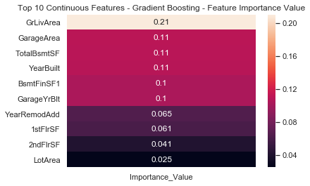

```python
sns.heatmap(data = gbr_rank_feat, annot=True )
plt.title('Top 10 Continuous Features - Gradient Boosting - Feature Importance Value')
```

### Conclusion of Part 1

At this point, I decided to make my own judgment about which features best describe the sales price. A few features stood out to me, based upon the results from above as well as common sense. Overall quality, the above ground living area in square feet, the year the house was built, and the neighborhood.

#### Overall Quality

The boxplot below shows a clear positive relationship between the overall quality and the sale price. The quality can be ranked from 1 to 10, with 1 being the worst and 10 being excellent. The better the overall quality of the house, the higher the sales price is.

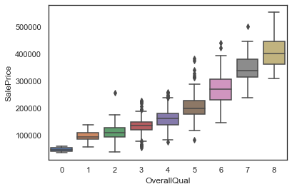

```python
overall_qual = X_train_cat_le["OverallQual"]
price = y_train
ax = sns.boxplot(x=overall_qual, y=price)
```

Below, we also see a positive relationship between the above ground living area and the sale price. However, I see a few points that have a lot of square feet but the price is still low. This is probably due to issues with other features of the house, which doesn't make the amount of space the house has above ground the strongest predictor in certain cases.

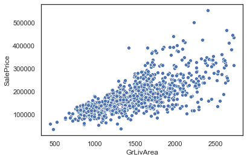

```python
living_area = train_cont["GrLivArea"]
price = y_train
ax = sns.scatterplot(x=living_area, y=price)
```

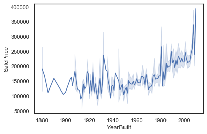

```python
yr_built = train_cont["YearBuilt"]
price = y_train
ax = sns.lineplot(x=yr_built, y=price)
```

In this boxplot, each number on the x-axis is label encoded and represents a different neighborhood. You can certainly see that each neighborhood has it's own price range with some outliers. however, there are also multiple neighborhoods with very similar ranges. I think it does influence the price point but may not be the best predictor.

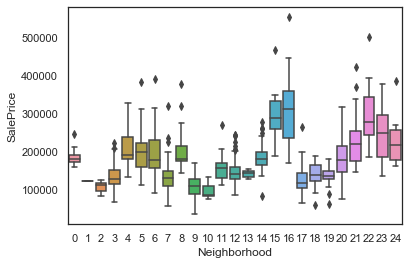

```python
neighbor = X_train_cat_le["Neighborhood"]
price = y_train
ax = sns.boxplot(x=neighbor, y=price)
```

Each of the features that stood out to me were more or less influential but the main feature that seemed to strongly describe the sales price is **Overall Quality**. I think there are some exceptions in the dataset, but for the most part I see strong growth in the sales price as the quality of the house improves. It may also take in multiple factors that make it a well rounded way to predict how expensive the house will be.

While it may be up for debate, I think the results from the different models/techniques, the graphs, and some domain knowledge supports this claim!